# Plot chord diagrams for string instruments using R

Detlef Groth, Schwielowsee, Germany

2022-02-12

bkcd - chords - mgraph - sbi

## NAME

*chords.R* - R environment and standalone application to create chord diagrams for string instruments.

## TABLE OF CONTENTS

- SYNOPSIS
- DESCRIPTION
- USAGE
- FUNCTIONS
  - chords$chord - generate chord diagrams for six-string instruments like the guitar
  - chords$halfsteps - calculate the distance between two notes
  - chords$notes - display fretboard note positions for string instruments like Guitar and Ukulele
  - chords$picking - generate fingerpicking diagrams for string instruments like Guitar and Ukulele
- EXAMPLES
- CITATION
- DOCUMENTATION
- LINKS
- TODOS
- CHANGELOG
- LICENSE / AUTHOR

## SYNOPSIS

Sourcing:

```
source("~/R/dlib/chords.R")
chord(chord="C",positions="X32010",fingerings="0RM0I0")
chord(chord="Dm",positions="XX0231",fingerings="000MRI")
```

Standalone application:

```
Rscript ~/R/dlib/chords.R --chords C:X32010:0RM0I0 Dm:XX0231:000MRI out.pdf
Rscript chords.R --chords --layout 2,3 \
         C:0003:000R Dm:2210:MRI0 Em:0432:0RMI \
         F:2010:M0I0 G7:0212:0RIM Am:2000:M000  GCEA-C-Dur.svg
Rscript ~/R/dlib/chords.R --help
Rscript ~/R/dlib/chords.R --docu # create documentation
```

## DESCRIPTION

The file *chords.R* contains the code for an R environment *chords* to create Chord diagrams for string instruments like Guitar and Ukulele.

Requirements:

- R standard installation
- Optional: Cairo package for SVG output
- Optional: tikzDevice package for LaTeX output

Public Functions:

- chords$chord - create chord diagrams

## USAGE

### Source chords.R

To use the functions in your own R programs and analysis just source the  
file `chords.R` into your R application. It is in principle recommended to place the  
file into the R folder in your HOME directory.

```r
source("chords.R")
```

All function of this file are added to an environment variable called *chords*.  
To have a look which variables and functions exists in this namesspace you can use the function call `ls(chords)`. Here is the output:

```r
ls(chords)
```

```
## [1] "chord"     "FILENAME"  "halfsteps" "notes"     "picking"   "VERSION"
```

Public methods names start with a lowercase letter. You should only use them in your R scripts.

```r
ls(chords,pattern="^[a-z]")
```

```
## [1] "chord"     "halfsteps" "notes"     "picking"
```

### Application chords.R

Alternatively, if you make the script executable and you  
move into a folder belonging to your PATH variable, you can use the script `chords.R` as a standalone executable you can directly from the terminal create chord charts. Here an invocation to create 6 chords for the C-Dur scale of an Ukulele in GCES tuning.

```
$ chords.R --chords C:0003:000R Dm:2210:MRI0 Em:0432:0RMI \
    F:2010:M0I0 G7:0212:0RIM Am:2000:M000  GCEA-C-Dur.png
```

Possible output file formats are :

- `.pdf` - using standard R graphics
- `.png` - using standard R graphics
- `.svg` - using Cairo-SVG device if available
- `.tikz` - using tikzDevice if available

## FUNCTIONS

**chords$chord(chord,positions,fingerings,…)**

> Creates a chord chart for string instruments such as Guitar and Ukulele..

> This function creates …

> Arguments:
> - *tuning* - character string which will be displayed at the bottom, if empty not shown, default: “EADGBE”
> - *chord* - the chord name which will be shown on top, if emtpy nothing will be shown, default: “D”
> - *nfrets* - number of frets to be displayed, default: 5
> - *cex* - scaling factor for text, default: 1
> - *cex.pch* - scaling character for the plotting symbols, default: 1
> - *positions* - indicator at which fret to press the string, X means skipping, 0 (zero) not fretting the string, default: “XX0232”
> - *fingerings* - which finger to choose (IMRP syntax - Index, Middle, Ring, Pinky), default: “000IRM”
> - *family* the font family to be used for all the text

> Examples:

> Below an example for Guitar chords in standard tuning for the key C-major.

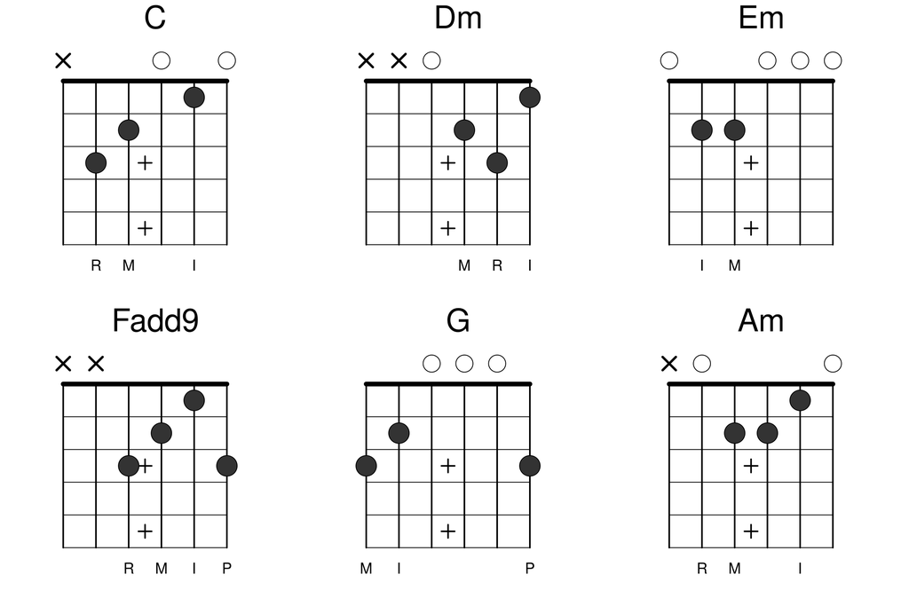

> ```r
> chord=chords$chord
> par(mfrow=c(2,3),mai=c(0.1,0.1,0.4,0.0))
> chord(chord="C",positions="X32010",fingerings="0RM0I0",tuning="")
> chord(chord="Dm",positions="XX0231",fingerings="000MRI",tuning="")
> chord(chord="Em",positions="022000",fingerings="0IM000",tuning="")
> chord(chord="Fadd9",positions="XX3213",fingerings="00RMIP",tuning="")
> chord(chord="G",positions="320003",fingerings="MI000P",tuning="")
> chord(chord="Am",positions="X02210",fingerings="0RM0I0",tuning="")
> ```

**chords$halfsteps(n1,n1)**

> Return the number of halfsteps from note n1 to note n2.

> Arguments:
> - *n1* - first note
> - *n2* - second note

> Returns: number of halfsteps to go from note 1 to note up the scale.

> Examples:

> ```r
> chords$halfsteps('C','C')
> ```

> ```
> ## [1] 0
> ```

> ```r
> chords$halfsteps('C','D')
> ```

> ```
> ## [1] 2
> ```

> ```r
> chords$halfsteps('D','C')
> ```

> ```
> ## [1] 10
> ```

> ```r
> chords$halfsteps('B','A#')
> ```

> ```
> ## [1] 11
> ```

> ```r
> chords$halfsteps('B','Bb')
> ```

> ```
> ## [1] 11
> ```

**chords$notes(nfrets,x,y,labels, …)**

> Creates fretboard plots for note display for string instruments such as Guitar or Ukulele.

> Arguments:
> - *nfrets* - the number of frets to display, default: 5
> - *nstrings* - the number of strings of the instrument, default: 4
> - *x* - x positions of the notes, default: c(0,0,0,2,3,3)
> - *y* - y positions of the notes, default: y=c(2,3,4,2,3,4),
> - *labels* - character vector for labels placed on the notes, default: empty strings
> - *col* - color(s) for the plot symbol, default: ‘grey90’
> - *…* - additional arguments forwarded to the plot function

> Examples:

> Below an example for the pentatonic notes of the C-major scale for a standard Ukulele.

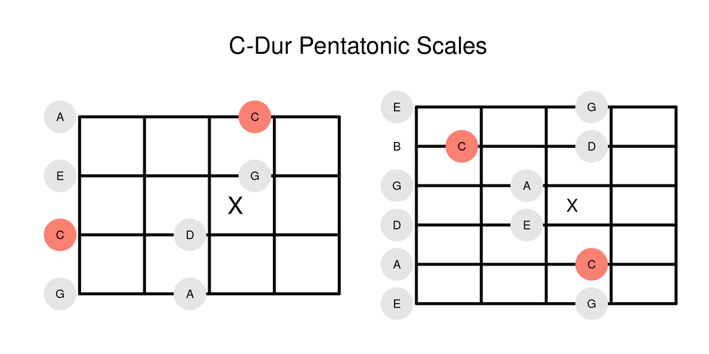

> ```r
> par(mfrow=c(1,2),mai=c(0.1,0.2,0.5,0.1),omi=c(0.2,0.3,0.6,0.2))
> chords$notes(nfrets=4,
>      x=c(0,0,0,0,2,3,3,2), y=c(1,2,3,4,2,3,4,1),
>      col=c("grey90","salmon",rep('grey90',4),'salmon'),
>      labels=c("G","C","E","A","D","G","C","A"))
> text(2.4,2.5,"X",cex=2)
> chords$notes(nfrets=4,nstrings=6,
>      x=c(rep(0,6),3, 2, 2, 1, 3, 3, 3), y=c(1:6,2, 3,4, 5, 5, 6, 1),
>      col=c(rep("grey90",4),'white','grey90','salmon',rep('grey90',2),'salmon',rep('grey90',2)),
>      labels=c("E","A","D","G","B","E", "C", "E", "A","C","D","G", "G"))
> text(2.4,3.5,"X",cex=1.5)
> mtext("C-Dur Pentatonic Scales",side=3,outer=TRUE,cex=2,line=-1)
> ```

**chords$picking(x,y,length,labels, …)**

> Creates fingerpicking tabulature for string instruments such as Guitar or Ukulele.

> Arguments:
> - *strings* - the strings of the instrument as character vector, default: character string which will be displayed at the bottom, if empty not shown, default: c(“D”,“G”,“B”,“E”)
> - *length* - length of the picking pattern, default: 8
> - *x* - x positions of the picking pattern, default: 1:8
> - *y* - y positions, position 1 is the lower string, default: y=c(2,3,1,4,2,3,1,4)
> - *labels* - character vector for labels placed on top of the picking symbols, default: rep(c(“T”,“I”,“T”,“R”),2)
> - *col* - color for the plot symbol, default: ‘grey90’
> - *lwd* - lwd for strings and vertical lines, default: 4
> - *cex.main* - scaling size for the title, default: 3
> - *…* - additional arguments forwarded to the plot function

> Examples:

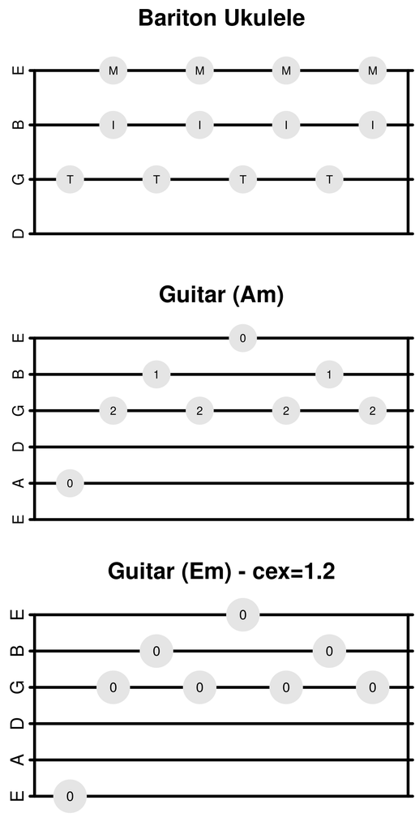

> ```r
> par(mfrow=c(3,1),mai=c(0.1,0.5,0.5,0.1))
>
> picking=chords$picking
> picking(x=c(1,2,2, 3,4,4, 5,6,6, 7,8,8),
>             y=rep(c(2,3,4),4),
>             labels=rep(c("T","I","M"),4),
>             main="Bariton Ukulele",cex.main=3)
> picking(strings=c("E","A","D","G","B","E"),
>         x=1:8,y=c(2,4,5,4,6,4,5,4),
>             labels=c(0,2,1,2,0,2,1,2),
>             main="Guitar (Am)",cex.main=3)
> picking(strings=c("E","A","D","G","B","E"),
>         x=1:8,y=c(1,4,5,4,6,4,5,4),
>             labels=rep(0,8),cex=1.2,
>             main="Guitar (Em) - cex=1.2",cex.main=3)
> ```

## EXAMPLES

Below a few more examples. Let’s start with the six main chords of the C major key for the Ukulele:

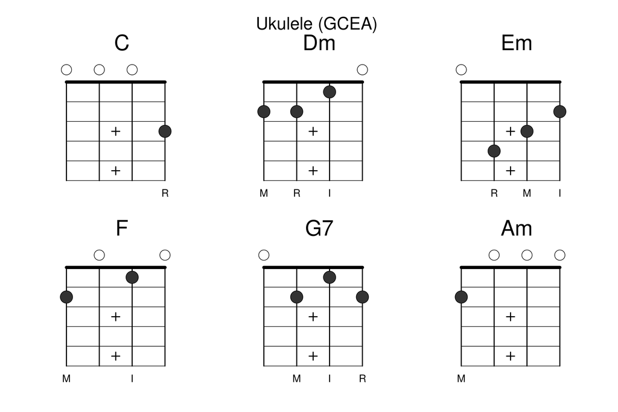

> ```r
> chord=chords$chord
> par(mfrow=c(2,3),omi=c(0.2,0.4,0.6,0.1),mai=c(0.1,0.1,0.4,0.0))
> chord(chord="C",positions="0003",fingerings="000R",tuning="")
> chord(chord="Dm",positions="2210",fingerings="MRI0",tuning="")
> chord(chord="Em",positions="0432",fingerings="0RMI",tuning="")
> chord(chord="F", positions="2010",fingerings="M0I0",tuning="")
> chord(chord="G7",positions="0212",fingerings="0MIR",tuning="")
> chord(chord="Am",positions="2000",fingerings="M000",tuning="")
> mtext("Ukulele (GCEA)",side=3,outer=TRUE,cex=2)
> ```

Now an other interesting chord progression for the Ukulele:

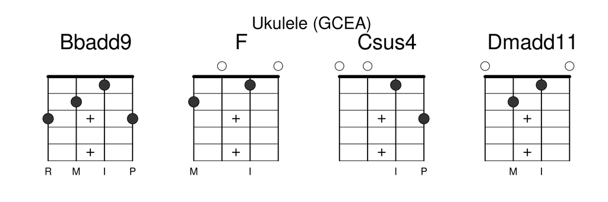

> ```r
> chord=chords$chord
> par(mfrow=c(1,4),omi=c(0.2,0.4,0.6,0.1),mai=c(0.1,0.1,0.4,0.0))
> chord(chord="Bbadd9",positions="3213",fingerings="RMIP",tuning="")
> chord(chord="F", positions="2010",fingerings="M0I0",tuning="")
> chord(chord="Csus4", positions="0013",fingerings="00IP",tuning="")
> chord(chord="Dmadd11", positions="0210",fingerings="0MI0",tuning="")
> mtext("Ukulele (GCEA)",side=3,outer=TRUE,cex=2)
> ```

Let’s now create a Guitar picking pattern over three chords  
with indication of the fretted strings, not with indications of the used finger:

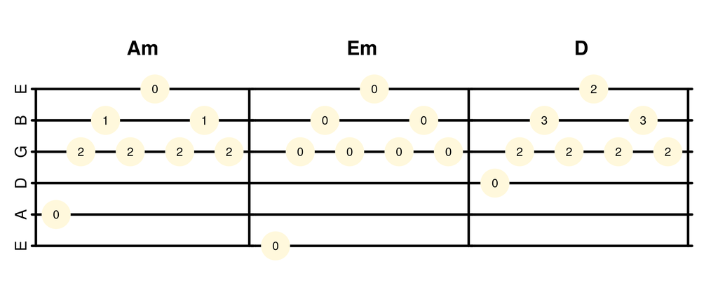

> ```r
> par(mfrow=c(1,3),mai=c(0.0,0.1,0.6,0.0),omi=c(0.5,0.5,0.5,0.5))
> picking=chords$picking
> col="cornsilk"
> picking(strings=c("E","A","D","G","B","E"),
>         x=1:8,y=c(2,4,5,4,6,4,5,4),
>             labels=c(0,2,1,2,0,2,1,2),
>             main="Am",cex.main=3,cex=1.2,col=col)
> picking(strings=c("E","A","D","G","B","E"),
>         x=1:8,y=c(1,4,5,4,6,4,5,4),
>             labels=rep(0,8),axis2=FALSE,
>             main="Em",cex.main=3,cex=1.2,col=col)
> picking(strings=c("E","A","D","G","B","E"),
>         x=1:8,y=c(3,4,5,4,6,4,5,4),
>             labels=c(0,2,3,2,2,2,3,2),axis2=FALSE,
>             main="D",cex.main=3,cex=1.2,col=col)
> ```

Setting the notes by hand, as could be seen in the notes-plot above,  
on the right positions is a little bit tedious.  
Think about setting this on longer fretboard diagrams.  
We can use the halfstep functionality to calculate automatically  
the the right positions:

```r
par(mai=c(0.4,0.4,0.4,0.1))
chords$notes(nfrets=8,nstrings=4,x=c(),y=c(),labels=c())
i=0
text(x=c(2.5,4.5,6.5,7.5),y=rep(2.5,4),'X',cex=1.5)
for (str in c('G','C','E','A')) {
    i=i+1
    for (pn in c('C','D','E','G','A')) {
       hs=chords$halfsteps(str,pn)
       if (hs<9) {
         col='grey90'
         if (pn=='C') { col ="salmon" }
         points(hs-0.5,i,col=col,pch=19,cex=6)
         text(hs-0.5,i,pn,cex=1.3)
       }
    }
}
```

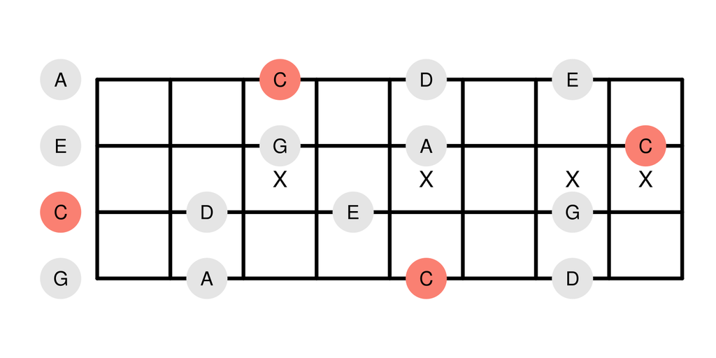

## CITATION

How to cite this script:

```
# notrun
@Misc{Groth2022chords,
  author =   {Detlef Groth},
  title =    {chords.{R} - {R} functions to create chord and fretboard diagrams for string instruments.},
  howpublished = {\url{https://github.com/mittelmark/Rcode}},
  year = {2022}
}
```

Groth, D. (2022). chords.{R} - {R} functions to create chord and fretboard diagrams for string instruments. https://github.com/mittelmark/Rcode

## DOCUMENTATION

This documentation was created directly from the file *chords.R* using the following commands in the terminal:

```
# notrun
Rscript chords.R --docu
```

The script `chords.R` can be executed directly from the command line as described above, using the docu flag all lines starting with  
the `#'` character sequence are extracted and then processed using the library rmarkdown which evaluates the embedded code chunks.

## LINKS

- [Javascript and Python tools](https://forum.codeselfstudy.com/t/displaying-guitar-chord-diagrams-with-javascript-and-python/2522)

## TODO’s

- Ukulele (done)
- Kapo display
- flexibility in placing the Chord indicator, top or bottom
- fret indicator on the right 3rd, 4th, etc.
- plotting scales “0000|0R111|0011|0101|001R” from top to bottom (R is root indicator)
- rotate the plot
- changing fonts as well in terminal application mode

## CHANGELOG

- 2022-01-30 (Version 0.1) - initial release
- 2022-02-07 (Version 0.2) - adapting circles and crosses all to polygons
- 2022-02-12 (Version 0.3) - adding fingerpicking and notes diagrams

## DISCLAIMER

There is no warranty of any kind! Use at your own risk!!

## LICENSE (MIT)

Copyright 2022 Detlef Groth, Scwielowsee, Germany

Permission is hereby granted, free of charge, to any person obtaining a copy of this software and associated documentation files (the “Software”), to deal in the Software without restriction, including without limitation the rights to use, copy, modify, merge, publish, distribute, sublicense, and/or sell copies of the Software, and to permit persons to whom the Software is furnished to do so, subject to the following conditions:

The above copyright notice and this permission notice shall be included in all copies or substantial portions of the Software.

THE SOFTWARE IS PROVIDED “AS IS”, WITHOUT WARRANTY OF ANY KIND, EXPRESS OR IMPLIED, INCLUDING BUT NOT LIMITED TO THE WARRANTIES OF MERCHANTABILITY, FITNESS FOR A PARTICULAR PURPOSE AND NONINFRINGEMENT. IN NO EVENT SHALL THE AUTHORS OR COPYRIGHT HOLDERS BE LIABLE FOR ANY CLAIM, DAMAGES OR OTHER LIABILITY, WHETHER IN AN ACTION OF CONTRACT, TORT OR OTHERWISE, ARISING FROM, OUT OF OR IN CONNECTION WITH THE SOFTWARE OR THE USE OR OTHER DEALINGS IN THE SOFTWARE.